**Aimee Moses**  
APMA 4301  
Spring 2020  
Professor Kyle Mandli

# Spatiotemporal SEIR Model with Social Distancing and Spatial Heterogeneity

## Background

The use of differential equations to model the spread of disease goes back almost a century. In 1927, Kermack and McKendrick proposed the first of a class of models referred to generally as "SIR Models," in which infection dynamics are modeled by a system of partial differential equations for different compartments of the total population. Kermack and McKendrick used the compartments: Susceptible (S), Infected (I), and Recovered (R). Since this first implementation, many variations have been proposed. They have been used to map the spread of a wide range of infectious diseases such as Rabies, Influenza, HIV, and Severe Acute Respiratory Syndrome (SARS). The models are used to study both future and past infection dynamics, optimize vaccine distribution, test social intervention strategies, and more. In this paper, I propose a model for the present COVID-19 pandemic. Here, I will present existing models with features that I find applicable to the current situation.

The most basic of this class of models considers infection and recovery as the only contributing factors to the movement in, out, and between the population compartments. Let $\kappa$ be the infectiousness of the disease, and $\alpha$ be the recovery rate. If we ignore the spatial spread of disease and consider only how the populations change with respect to time, then our model becomes the following system of ordinary differential equations:

$$ \begin{align} \frac{dS}{dt} &= -\kappa \frac{SI}{N} \\ \frac{dI}{dt} &= \kappa \frac{SI}{N} - \alpha I \\ \frac{dR}{dt} &= \alpha I \end{align} $$

where the total population is $N = S + I + R$. From this definition and the linearity of the derivative, it is easy to see that the total population is constant over time.

$$ \begin{align} \frac{dN}{dt} &= \frac{dS}{dt} + \frac{dI}{dt} + \frac{dR}{dt} \\ &= -\kappa \frac{SI}{N} + \kappa \frac{SI}{N} - \alpha I + \alpha I \\ &= 0 \end{align} $$

We assume that $S(t)$, $I(t)$, and $R(t)$ be non-negative, continuous functions. The movement from the Susceptible to the Infected compartments is called the "incidence of infection." In this case, we have "proportionate mixing" where transmission of the infection is dependent on the contact between the Susceptible and Infected individuals. $\kappa\frac I N$ is known as the "force of infection" and indicates the effective per capita transmission. Often, we take $N = 1$ and interpret the compartment population values as proportions of the total population.

From here, there are many ways in which we can increase the complexity and applicability of the model. We can allow for net population change by incorporating natural birth and death rates, $\mu$ and $\gamma$, respectively:

$$ \begin{align} \frac{dS}{dt} &= \mu N -\kappa \frac{SI}{N} - \gamma S \\ \frac{dI}{dt} &= \kappa \frac{SI}{N} - \alpha I - \gamma I\\ \frac{dR}{dt} &= \alpha I - \gamma R \end{align} $$

Now, the total population is not necessarily constant. We have:

$$ \begin{align} \frac{dN}{dt} &= \frac{dS}{dt} + \frac{dI}{dt} + \frac{dR}{dt} \\ &= \mu N -\kappa \frac{SI}{N} -\gamma S + \kappa \frac{SI}{N} - \alpha I - \gamma I + \alpha I - \gamma R \\ &= (\mu - \gamma) N \end{align} $$

Thus, the system is constant if $\mu = \gamma$ and stable as long as $\mu \leq \gamma$. A common alteration from this point is the use of a different incidence of infection. In 1978, Capasso and Serio introduced a nonlinear and non-monotone "saturated" incidence of infection. Therefore, the population mixing increases with population size for small numbers of Infected individuals, but decreases with "saturation" or crowding when the Infected population is large. Xiao and Ruan (2007) discussed this and other common functions used for incidence of infection. For their investigation of the SARS outbreak, they chose to use a similar incidence of infection:

$$ g(I) = \frac{\kappa IS}{1 + \omega I^2} $$

This transmission behavior reflects a "psychological" effect of a large Infected population. Thus, they argue that it parallels protective measures and policies such as "border screening, mask wearing, quarantine, isolation, etc." (Xiao & Ruan, 2007). Derrick and van der Driessche (1993) used an unspecified nonlinear incidence of infection for their SIRS model. As the name suggests, a SIRS model differs from the SIR model in that the Recovered individuals will eventually lose their immunity and return to the Susceptible population. Another notable feature of their model was the addition of the possibility of dying from the disease. This additional death rate is fairly common, but Derrick and van der Driessche went one step further by including deaths of both currently Infected people as well as those already Recovered. This accounts for a lasting impact of the disease on the health of affected individuals.

SIR models are not limited to only Susceptible, Infected, and Recovered compartments of the population. A dramatic example of this comes from another article based on the SARS outbreak. In Gumel et al. (2004), the authors propose a model with six population compartments: Susceptible (S), Exposed (E; asymptomatic, contagious), Quarantined (Q; exposed + segregated), Infected (I; symptomatic, contagious), Isolated (J; infected + segregated), and Recovered. Population dynamics are modeled as follows:

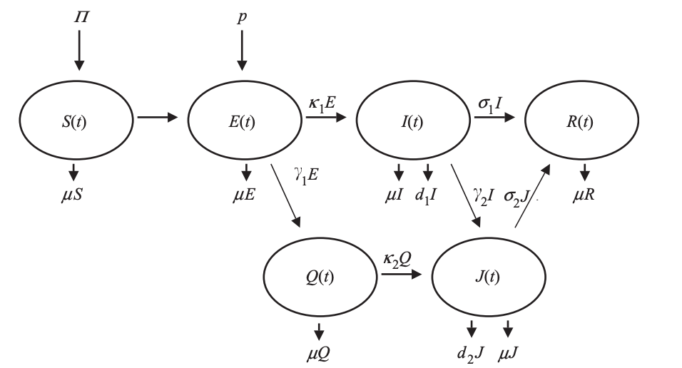

where $\Pi = $ net influx from birth, immigration, emigration, etc., $\beta = $ transmission coefficient, and $p = $ rate of undetected entry of Exposed individuals. Recall that Derrick and van der Driessche used different rates for death from the disease for the Infected and Recovered populations. Here, Gumel et al., take that to the extreme by specifying different parameters by population for: transmission by each of the contagious populations ($\epsilon$), rate of segregation to Quarantined or Isolated ($\gamma$), rate of symptom development ($\kappa$), rate of disease-related death ($d$), and rate of recovery ($\sigma$).

The above studies all chose to consider only a single value for the each population compartment at each point in time. As such, their models take the form of systems of ordinary differential equations with respect to time, requiring only an initial condition. Many SIR models, however, also take into account population change over the variable of space. Space is incorporated with a diffusion term for each population compartment. For example, consider a version of the SIR model proposed by Neilan and Lenhart (2011) to model the spread of Rabies:

$$ \begin{align} \frac{\partial S}{\partial t} &= a_{11}(x, y)S_{xx} + a_{22}(x, y)S_{yy} + \mu (S + R) - \gamma_1S - \beta SI \\ \frac{\partial I}{\partial t} &= a_{11}(x, y)I_{xx} + a_{22}(x, y)I_{yy} - \gamma_2 I + \beta SI \\ \frac{\partial R}{\partial t} &= a_{11}(x, y)R_{xx} + a_{22}(x, y)R_{yy} - \gamma_1R\\ \end{align} $$

for all $(x,y,t) \in [0,L] \times [0,L] \times [0, T]$ with initial conditions:

$$ S(x, y, 0) = S_0(x, y), \quad I(x, y, 0) = I_0(x, y), \quad R(x, y, 0) = R_0(x, y) $$

and homogeneous Neumann ("No-Flux") boundary conditions:

$$ \begin{align} S_x &= I_x = R_x = 0 \quad \text{ on } \quad x = 0 \text{ and } x = L \text{ for all } t \in [0, T] \\ S_y &= I_y = R_y = 0 \quad \text{ on } \quad y = 0 \text{ and } y = L \text{ for all } t \in [0, T] \end{align} $$

Note that the diffusion coefficients $a_{11}$ and $a_{22}$ depend on $x$ and $y$. This is one way in which SIR models can account for heterogeneity across the spatial domain. In this case, the authors used piecewise functions for the diffusion coefficients to reflect different degrees of movement in an area with varying physical geography (e.g., lake, forest, etc.). The initial conditions they used also reflect this heterogeneity.

There are countless other variations on the Kermack-McKendrick SIR model in epidemiology literature. They differ on a number of aspects including spatial dimensions, population compartments, parameters included, incidence of infection, and more. Below, I outline a version of the model intended to parallel the current COVID-19 pandemic.

## Defining the Model

By letting the diffusion coefficients vary across the domain, I can simulate movement within and between different regions (e.g., countries, states). For example, I can demonstrate the effects of a travel ban by drawing borders with very low diffusion between partitions of the domain. I could also let different partitions have different diffusion rates to simulate regions with varying levels of precautions in place.

The psychological factor, $\omega$, is one way in which the model can account for social distancing. As Xiao and Ruan (2007) discussed, using a non-monotone, nonlinear transmission function accounts for "crowding." In our case, the crowding is a function of only the Infected population, so it is more accurately interpreted as behavioral changes in response to widespread disease. This can encompass any behaviors that change as a result of the growing infection, such as shelter-in-place policies, social distancing, wearing masks, etc.

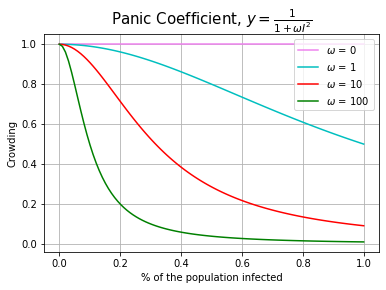

In this model, both the Exposed and Infected populations are contagious, and can transmit the disease. However, they have different transmission coefficients. This reflects the impact that being symptomatic (i.e., Infected) has on infectiousness. For instance, Infected individuals probably cough and sneeze more than the asymptomatic Exposed individuals. If the virus is transmitted through air or bodily fluids, like COVID-19, these symptoms likely make the Infected population more contagious than the Exposed population.

Combining these elements results in the following system, with $t \geq 0$:

$$ \begin{align} \frac{\partial S}{\partial t} &= a(x,y)\nabla^2 S + \gamma\left( S + E + I + R \right) - \left( \frac{\kappa_1I + \kappa_2E}{1 + \omega I^2} \right)S - \mu S \\ \frac{\partial E}{\partial t} &= a(x,y)\nabla^2 E + \left( \frac{\kappa_1I + \kappa_2E}{1 + \omega I^2} \right)S - \left( \mu + \sigma \right)E \\ \frac{\partial I}{\partial t} &= a(x,y)\nabla^2 I + \sigma E - \alpha I - \left( \mu + \delta_1 \right)I \\ \frac{\partial R}{\partial t} &= a(x,y)\nabla^2 R + \alpha I - \left( \mu + \delta_2 \right)R \end{align} $$

As the literature recommends (e.g., Neilan & Lenhart, 2011), the model uses homogeneous Neumann ("No-Flux") boundary conditions and Dirichlet initial conditions:

$$ \begin{align} S_x &= E_x = I_x = R_x = 0 \quad \text{ on } \quad x = 0 \text{ and } x = L \text{ for all } t \geq 0 \\ S_y &= E_y = I_y = R_y = 0 \quad \text{ on } \quad y = 0 \text{ and } y = L \text{ for all } t \geq 0 \end{align} $$

$$ S(0, x, y) = S_0(x, y), \quad E(0, x, y) = E_0(x, y), \quad I(0, x, y) = I_0(x, y), \quad R(0, x, y) = R_0(x, y) $$

## Implementation

To implement the model numerically, I used an Implicit-Explicit (IMEX) method with Forward and Backward Euler steps. At each time step, the four population components take a Forward Euler step with the reaction terms (i.e., all except for diffusion), followed by a Backward Euler step with the diffusion terms.

To simplify our discussion, let $U = \begin{bmatrix} S \\ E \\ I \\ R \end{bmatrix}$ and $F(U) = \begin{bmatrix} \gamma\left( S + E + I + R \right) - \left( \frac{\kappa_1I + \kappa_2E}{1 + \omega I^2} \right)S - \mu S \\ \left( \frac{\kappa_1I + \kappa_2E}{1 + \omega I^2} \right)S - \left( \mu + \sigma \right)E \\ \sigma E - \alpha I - \left( \mu + \delta_1 \right)I \\ a(x,y)\nabla^2 R + \alpha I - \left( \mu + \delta_2 \right)R \end{bmatrix}$.

Then we can write the model as:

$$ U = a(x,y)\nabla^2U + F(U) $$

or

$$ U = \mathcal{A} U + \mathcal{B} U $$

where $\mathcal{A}$ is the stiff diffusion operator and $\mathcal{B}$ is the non-stiff reaction operator.

Our IMEX method then becomes:

$$ \begin{align} U^{n+1} &= U^n + \Delta t(\mathcal{A}U^{n+1} + \mathcal{B}U^n) \\ U^{n+1} &= U^n + \Delta t\mathcal{A}U^{n+1} + \Delta t\mathcal{B}U^n \\ \\ U^\ast &= U^n + \Delta t\mathcal{B}U^n \\ U^{n+1} &= U^\ast + \Delta t\mathcal{A}U^{n+1} \end{align} $$

Forward Euler step (Explicit): $$ \begin{align} S^\ast &= S^n + \Delta t \left[ \gamma\left( S^n + E^n + I^n + R^n \right) - \left( \frac{\kappa_1I^n + \kappa_2E^n}{1 + \omega (I^n)^2} \right)S^n - \mu S^n \right] \\ E^\ast &= E^n + \Delta t \left[ \left( \frac{\kappa_1I^n + \kappa_2E^n}{1 + \omega (I^n)^2} \right)S^n - \left( \mu + \sigma \right)E^n \right] \\ I^\ast &= I^n + \Delta t \left[ \sigma E^n - \alpha I^n - \left( \mu + \delta_1 \right)I^n \right] \\ R^\ast &= R^n + \Delta t \left[ \alpha I^n - \left( \mu + \delta_2 \right)R^n \right] \end{align} $$

Backward Euler step (Implicit): $$ \begin{align} S^{n+1} &= S^\ast + \Delta t a(x,y) \nabla^2 S^{n+1} \\ E^{n+1} &= E^\ast + \Delta t a(x,y) \nabla^2 E^{n+1} \\ I^{n+1} &= I^\ast + \Delta t a(x,y) \nabla^2 I^{n+1} \\ R^{n+1} &= R^\ast + \Delta t a(x,y) \nabla^2 R^{n+1} \end{align} $$

In order to evaluate the Backward Euler step, I needed to discretize the Laplacian operator. For this I used the 9-point stencil. I ordered the unknown grid points with natural ordering so that I could create a coefficient matrix for the stencil.

The 9-point stencil:

$$ \nabla^2 u_{ij} \approx \frac{1}{6 \Delta x^2} \left(4 U_{i-1,j} + 4 U_{i+1,j} + 4 U_{i,j-1} + 4 U_{i,j+1} + U_{i-1,j-1} + U_{i+1,j-1} + U_{i+1,j+1} + U_{i-1,j+1} -20 U_{i,j} \right) $$

Natural ordering:

$$ U = [U_{1, 1}, U_{2, 1}, \ldots, U_{m-1,1}, U_{m, 1}, U_{1, 2}, U_{22},\ldots, U_{m-1,m}, U_{mm}] $$

We can write the 9-point stencil as a sparse matrix, $A$, dotted with the vector $U$. $A$ is defined as:

$$ A = \frac{1}{6\Delta x^2} \begin{bmatrix} T & S \\ S & T & S \\ & S & T & S \\ & & \ddots & \ddots & \ddots \\ & & & S & T & S \\ & & & & S & T \end{bmatrix} $$

where the matrices $T$ and $S$ are:

$$ T = \begin{bmatrix} -20 & 4 \\ 4 & -20 & 4 \\ & 4 & -20 & 4 \\ & & \ddots & \ddots & \ddots \\ & & & 4 & -20 & 4 \\ & & & & 4 & -20 \end{bmatrix}, \quad S = \begin{bmatrix} 4 & 1 \\ 1 & 4 & 1 \\ & 1 & 4 & 1 \\ & & \ddots & \ddots & \ddots \\ & & & 1 & 4 & 1 \\ & & & & 1 & 4 \end{bmatrix} $$

I then modified these matrices to incorporate the No-Flux boundary conditions. On the boundaries, I used a centered difference to approximate the derivative and set it equal to $0$:

$$ \frac{\partial u_{j}}{\partial t} \approx \frac{U_{j+1} - U_{j-1}}{2\Delta x} = 0 \\ U_{j+1} = U_{j-1} $$

Then the matrix $A$ becomes:

$$ A = \frac{1}{6\Delta x^2} \begin{bmatrix} T & 2S \\ S & T & S \\ & S & T & S \\ & & \ddots & \ddots & \ddots \\ & & & S & T & S \\ & & & & 2S & T \end{bmatrix} $$

where the matrices $T$ and $S$ are now:

$$ T = \begin{bmatrix} -20 & 8 \\ 4 & -20 & 4 \\ & 4 & -20 & 4 \\ & & \ddots & \ddots & \ddots \\ & & & 4 & -20 & 4 \\ & & & & 8 & -20 \end{bmatrix}, \quad S = \begin{bmatrix} 4 & 2 \\ 1 & 4 & 1 \\ & 1 & 4 & 1 \\ & & \ddots & \ddots & \ddots \\ & & & 1 & 4 & 1 \\ & & & & 2 & 4 \end{bmatrix} $$

### Import packages

```python
from __future__ import print_function
%matplotlib inline

import numpy
import matplotlib.pyplot as plt
import scipy.sparse as sparse
import scipy.sparse.linalg as linalg
```

### Define 'reaction' terms

```python
def s_change(S, E, I, R, gamma, mu, kappa1, kappa2, omega):
    """
    Computes the change in the SUSCEPTIBLE population (other than diffusion).

    :Input:
     - *S* (float) the current susceptible population
     - *E* (float) the current exposed population
     - *I* (float) the current infected population
     - *R* (float) the current recovered population
     - *gamma* (float) birth rate
     - *mu* (float) natural death rate
     - *kappa1* (float) transmission coefficient for exposed
     - *kappa2* (float) transmission coefficient for infected
     - *omega* (float) panic factor

    :Output:
     - *dS* (float) the change in the susceptible population (other than diffusion) for a single time step
    """
    dS = S * (- mu - (kappa1 * E + kappa2 * I)/(1 + omega*I**2)) + gamma * (S + E + I + R)
    return dS

def e_change(S, E, I, R, mu, kappa1, kappa2, omega, sigma):
    """
    Computes the change in the EXPOSED population (other than diffusion).

    :Input:
     - *S* (float) the current susceptible population
     - *E* (float) the current exposed population
     - *I* (float) the current infected population
     - *R* (float) the current recovered population
     - *mu* (float) natural death rate
     - *kappa1* (float) transmission coefficient for exposed
     - *kappa2* (float) transmission coefficient for infected
     - *omega* (float) panic factor
     - *sigma* (float) rate of symptom development

    :Output:
     - *dE* (float) the change in the exposed population (other than diffusion) for a single time step
    """
    dE = S * (kappa1 * E + kappa2 * I)/(1 + omega*I**2) - E * (mu + sigma)
    return dE

def i_change(S, E, I, R, mu, sigma, delta, alpha):
    """
    Computes the change in the INFECTED population (other than diffusion).

    :Input:
     - *S* (float) the current susceptible population
     - *E* (float) the current exposed population
     - *I* (float) the current infected population
     - *R* (float) the current recovered population
     - *mu* (float) natural death rate
     - *sigma* (float) rate of symptom development
     - *delta* (float) additional death rate of infected population due to illness
     - *alpha* (float) rate of recovery

    :Output:
     - *dI* (float) the change in the infected population (other than diffusion) for a single time step
    """
    dI = E * sigma - I * (mu + delta + alpha)
    return dI

def r_change(S, E, I, R, mu, alpha, beta):
    """
    Computes the change in the RECOVERED population (other than diffusion).

    :Input:
     - *S* (float) the current susceptible population
     - *E* (float) the current exposed population
     - *I* (float) the current infected population
     - *R* (float) the current recovered population
     - *mu* (float) natural death rate
     - *alpha* (float) rate of recovery
     - *beta* (float) additional death rate of recovered population due to illness

    :Output:
     - *dR* (float) the change in the recovered population (other than diffusion) for a single time step
    """
    dR = I * alpha - R * (mu + beta)
    return dR
```

### Discretize spatial diffusion

```python
def laplacian(L, m):
    """
    Constructs a sparse matrix that disretizes the 2D Laplacian.
    Uses a 9-point stencil and No-Flux boundary conditions.

    :Input:
     - *L* (float) length of one side of the domain (assumes a square domain starting at the origin)
     - *m* (integer) number of points to use in the approximation

    :Output:
     - *A* (matrix) sparse matrix representation of discretized Laplacian
    """
    delta_x = L / (m + 1)

    e = numpy.ones(m)
    T = numpy.zeros((m,m))
    T += numpy.diag(4 * e[1:], -1)
    T += numpy.diag(-20 * e, 0)
    T += numpy.diag(4 * e[1:], 1)
    T[0,1] = 8 ; T[-1,-2] = 8

    S = numpy.zeros((m,m))
    S += numpy.diag(e[1:], -1)
    S += numpy.diag(4 * e, 0)
    S += numpy.diag(e[1:], 1)
    S[0,1] = 2 ; S[-1,-2] = 2


    C = numpy.zeros((m,m))
    C += numpy.diag(e[1:], -1)
    C += numpy.diag(e[1:], 1)
    C[0,:] *= 2
    C[-1,:] *= 2

    I = numpy.diag(e, 0)

    A = sparse.kron(I, T) + sparse.kron(C, S)

    A /= (6 * delta_x**2)
    A = A.todia()

    return A
```

### Define Forward and Backward Euler Steps

```python
def backward_euler_diffusion_step(S, E, I, R, A, delta_t, diff):
    """
    Take a single backward euler step on the diffusion component

    :Input:
     - *S* (vector) the current susceptible population at each location [i,j] (natural ordering)
     - *E* (vector) the current exposed population at each location [i,j] (natural ordering)
     - *I* (vector) the current infected population at each location [i,j] (natural ordering)
     - *R* (vector) the current recovered population at each location [i,j] (natural ordering)
     - *A* (sparse matrix) laplacian discretization
     - *delta_t* (float) time step
     - *diff* (matrix) diffusion coefficient

    :Output:
     - *S* (vector) the current susceptible population at each location [i,j] (natural ordering)
     - *E* (vector) the current exposed population at each location [i,j] (natural ordering)
     - *I* (vector) the current infected population at each location [i,j] (natural ordering)
     - *R* (vector) the current recovered population at each location [i,j] (natural ordering)
    """
    B = numpy.dot(diff, A.todense())
    C = sparse.csr_matrix(B)

    S = linalg.spsolve((sparse.eye(A.shape[0]) - delta_t * C), S)
    E = linalg.spsolve((sparse.eye(A.shape[0]) - delta_t * C), E)
    I = linalg.spsolve((sparse.eye(A.shape[0]) - delta_t * C), I)
    R = linalg.spsolve((sparse.eye(A.shape[0]) - delta_t * C), R)
    return S, E, I, R

def forward_euler_reaction_step(S, E, I, R, delta_t, dS, dE, dI, dR):
    """
    Take a single forward euler step on the reaction component

    :Input:
     - *S* (float) the current susceptible population
     - *E* (float) the current exposed population
     - *I* (float) the current infected population
     - *R* (float) the current recovered population
     - *delta_t* (float) time step
     - *dS* (function) movement in and out of susceptible population
     - *dE* (function) movement in and out of exposed population
     - *dI* (function) movement in and out of infected population
     - *dR* (function) movement in and out of recovered population

    :Output:
     - *S* (vector) the current susceptible population at each location [i,j]
     - *E* (vector) the current exposed population
     - *I* (vector) the current infected population
     - *R* (vector) the current recovered population
    """
    S_new = S + delta_t * dS(S, E, I, R)
    E_new = E + delta_t * dE(S, E, I, R)
    I_new = I + delta_t * dI(S, E, I, R)
    R_new = R + delta_t * dR(S, E, I, R)
    return S_new, E_new, I_new, R_new
```

### Bring it all together as an IMEX solver

```python
def imex_solver(m, L, t_final, S_0, E_0, I_0, R_0, gamma, mu, kappa1,
                kappa2, sigma, delta, alpha, beta, omega, diff):
    """
    Computes population of each population component across a square domain over time.
    Graphs the population levels every few time steps.

    :Input:
     - *m* (int) number of grid points in each direction of the domain
     - *L* (int) length of each side of the domain

     - *S_0* (matrix) the initial susceptible population
     - *E_0* (matrix) the initial exposed population
     - *I_0* (matrix) the initial infected population
     - *R_0* (matrix) the initial recovered population

     - *gamma* (float) birth rate
     - *mu* (float) natural death rate
     - *kappa1* (float) transmission coefficient for exposed
     - *kappa2* (float) transmission coefficient for infected
     - *sigma* (float) rate of symptom development
     - *delta* (float) additional death rate of infected population due to illness
     - *alpha* (float) rate of recovery
     - *beta* (float) additional death rate of recovered population due to illness
     - *omega* (float) panic factor
     - *diff* (matrix) diffusion coefficient

     :Output:
      - *S* (matrix) susceptible population across the domain at the final time step
      - *E* (matrix) exposed population across the domain at the final time step
      - *I* (matrix) infected population across the domain at the final time step
      - *R* (matrix) recovered population across the domain at the final time step
    """

    # Alias reaction functions with the above parameters
    dS = lambda S, E, I, R: s_change(S, E, I, R, gamma, mu, kappa1, kappa2, omega)
    dE = lambda S, E, I, R: e_change(S, E, I, R, mu, kappa1, kappa2, omega, sigma)
    dI = lambda S, E, I, R: i_change(S, E, I, R, mu, sigma, delta, alpha)
    dR = lambda S, E, I, R: r_change(S, E, I, R, mu, alpha, beta)

    # Set up grid
    delta_x = L / (m + 1)
    x = numpy.linspace(0, L, m)
    y = numpy.linspace(0, L, m)
    Y, X = numpy.meshgrid(y, x)

    # Time discretization
    t = 0.0
    delta_t = delta_x
    num_steps = int(numpy.round(t_final / delta_t))
    t_array = numpy.linspace(0, t_final, num_steps)

    # Initial Conditions
    S = S_0.reshape(-1)
    E = E_0.reshape(-1)
    I = I_0.reshape(-1)
    R = R_0.reshape(-1)
    A = laplacian(L, m)


    # Evolve in time
    for j in range(num_steps):
        S, E, I, R = forward_euler_reaction_step(S, E, I, R, delta_t, dS, dE, dI, dR)
        S, E, I, R = backward_euler_diffusion_step(S, E, I, R, A, delta_t, diff)

        S_output = S.reshape((m, m))
        E_output = E.reshape((m, m))
        I_output = I.reshape((m, m))
        R_output = R.reshape((m, m))

        t += delta_t



    return S_output, E_output, I_output, R_output
```

## Numerical Convergence Tests

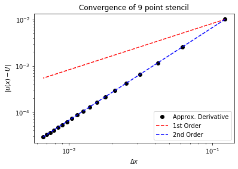

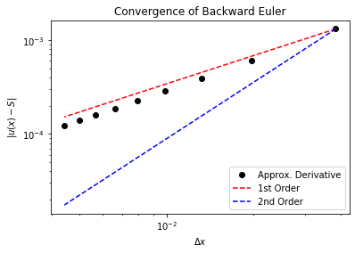

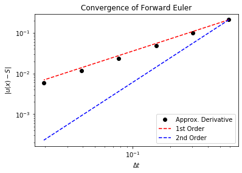

## Numerical Analysis

### Local Truncation Error

We will now determine the local truncation error, $\tau$, of our IMEX method. Let $A$ be the discretization of the Laplacian and $F(U)$ hold the reaction terms. We define $\tau$ as follows:

$$ U_{ij}^{n+1} = U_{ij}^n + \Delta t A U_{ij}^{n+1} + \Delta t F(U_{ij}^n) \\ \frac{U_{ij}^{n+1} - U_{ij}^n}{\Delta t} = A U_{ij}^{n+1} + F(U_{ij}^n) \\ \tau^n_{ij} = \tau(x_i, y_j, t^n) = \frac{U_{ij}^{n+1} - U_{ij}^n}{\Delta t} - A U_{ij}^{n+1} - F(U_{ij}^n) $$$$ \begin{align} \tau^n_{ij} &= \frac{U_{ij}^{n+1} - U_{ij}^n}{\Delta t} - \frac{1}{6\Delta x^2}\left( -20U_{ij}^{n+1} + 4U_{i+1, j}^{n+1} + 4U_{i-1, j}^{n+1} + 4U_{i,j + 1}^{n+1} + 4U_{i,j-1}^{n+1} + U_{i+1,j+1}^{n+1} + U_{i+1,j-1}^{n+1} + U_{i-1, j+1}^{n+1} + U_{i-1, j-1}^{n+1}\right) - F(U^n_{ij}) \\ &= \frac{u(x,y,t + \Delta t) - u(x,y,t)}{\Delta t} - \frac{1}{6\Delta x^2}\left( -20u(x,y,t+\Delta t) + 4u(x+\Delta x, y, t+\Delta t) + 4u(x-\Delta x, y, t+\Delta t) + 4u(x, y+\Delta x, t+\Delta t) + 4u(x, y-\Delta x, t+\Delta t) + u(x+\Delta x, y+\Delta x, t+\Delta t) + u(x+\Delta x, y-\Delta x, t+\Delta t) + u(x-\Delta x, y+\Delta x, t+\Delta t) + u(x-\Delta x, y-\Delta x, t+\Delta t) \right) - F(u(x,y,t)) \end{align} $$

We then use Taylor series to expand the terms about $(x_i, y_j, t^n)$. The corresponding Taylor expansions are:

$$ \begin{align} u(x, y, t + \Delta t) &= u + \Delta t u_t + \frac{\Delta t^2}{2}u_{tt} + \frac{\Delta t^3}{6}u_{ttt} + \cdots \\ u(x + \Delta x, y, t + \Delta t) &= u + \Delta t u_t + \Delta x u_x + \frac{\Delta t^2}{2}u_{tt} + \Delta t\Delta x u_{tx} + \frac{\Delta x^2}{2}u_{xx} + \frac{\Delta t^3}{6}u_{ttt} + \frac{\Delta t\Delta x^2}{2}u_{txx} + \frac{\Delta t^2\Delta x}{2} u_{ttx} + \frac{\Delta x^3}{6}u_{xxx} + \cdots \\ u(x - \Delta x, y, t + \Delta t) &= u + \Delta t u_t - \Delta x u_x + \frac{\Delta t^2}{2}u_{tt} - \Delta t\Delta x u_{tx} + \frac{\Delta x^2}{2}u_{xx} + \frac{\Delta t^3}{6}u_{ttt} + \frac{\Delta t\Delta x^2}{2}u_{txx} - \frac{\Delta t^2\Delta x}{2} u_{ttx} - \frac{\Delta x^3}{6}u_{xxx} + \cdots \\ u(x, y + \Delta x, t + \Delta t) &= u + \Delta t u_t + \Delta x u_y + \frac{\Delta t^2}{2}u_{tt} + \Delta t\Delta x u_{ty} + \frac{\Delta x^2}{2}u_{yy} + \frac{\Delta t^3}{6}u_{ttt} + \frac{\Delta t\Delta x^2}{2}u_{tyy} + \frac{\Delta t^2\Delta x}{2} u_{tty} + \frac{\Delta x^3}{6}u_{yyy} + \cdots \\ u(x, y - \Delta x, t + \Delta t) &= u + \Delta t u_t - \Delta x u_y + \frac{\Delta t^2}{2}u_{tt} - \Delta t\Delta x u_{ty} + \frac{\Delta x^2}{2}u_{yy} + \frac{\Delta t^3}{6}u_{ttt} + \frac{\Delta t\Delta x^2}{2}u_{tyy} - \frac{\Delta t^2\Delta x}{2} u_{tty} - \frac{\Delta x^3}{6}u_{yyy} + \cdots \end{align} $$

$$ u(x + \Delta x, y + \Delta x, t + \Delta t) = u + \Delta t u_t + \Delta x u_x + \Delta x u_y + \frac{\Delta t^2}{2}u_{tt} + \frac{\Delta x^2}{2}u_{xx} + \frac{\Delta x^2}{2}u_{yy} + \Delta t\Delta x u_{tx} + \Delta t\Delta x u_{ty} + \Delta x^2u_{xy} + \frac{\Delta t^3}{6}u_{ttt} + \frac{\Delta x^3}{6}u_{xxx} + \frac{\Delta x^3}{6}u_{yyy} + \frac{\Delta t^2\Delta x}{2}u_{ttx} + \frac{\Delta t^2\Delta x}{2}u_{tty} + \frac{\Delta t\Delta x^2}{2}u_{txx} + \frac{\Delta t\Delta x^2}{2}u_{tyy} + \frac{\Delta x^3}{2}u_{xyy} + \frac{\Delta x^3}{2}u_{xxy} + \Delta t\Delta x^2u_{txy} + \cdots\\ $$

$$ u(x - \Delta x, y + \Delta x, t + \Delta t) = u + \Delta t u_t - \Delta x u_x + \Delta x u_y + \frac{\Delta t^2}{2}u_{tt} + \frac{\Delta x^2}{2}u_{xx} + \frac{\Delta x^2}{2}u_{yy} - \Delta t\Delta x u_{tx} + \Delta t\Delta x u_{ty} - \Delta x^2u_{xy} + \frac{\Delta t^3}{6}u_{ttt} - \frac{\Delta x^3}{6}u_{xxx} + \frac{\Delta x^3}{6}u_{yyy} - \frac{\Delta t^2\Delta x}{2}u_{ttx} + \frac{\Delta t^2\Delta x}{2}u_{tty} + \frac{\Delta t\Delta x^2}{2}u_{txx} + \frac{\Delta t\Delta x^2}{2}u_{tyy} - \frac{\Delta x^3}{2}u_{xyy} + \frac{\Delta x^3}{2}u_{xxy} - \Delta t\Delta x^2u_{txy} + \cdots $$

$$ u(x + \Delta x, y - \Delta x, t + \Delta t) = u + \Delta t u_t + \Delta x u_x - \Delta x u_y + \frac{\Delta t^2}{2}u_{tt} + \frac{\Delta x^2}{2}u_{xx} + \frac{\Delta x^2}{2}u_{yy} + \Delta t\Delta x u_{tx} - \Delta t\Delta x u_{ty} - \Delta x^2u_{xy} + \frac{\Delta t^3}{6}u_{ttt} + \frac{\Delta x^3}{6}u_{xxx} - \frac{\Delta x^3}{6}u_{yyy} + \frac{\Delta t^2\Delta x}{2}u_{ttx} - \frac{\Delta t^2\Delta x}{2}u_{tty} + \frac{\Delta t\Delta x^2}{2}u_{txx} + \frac{\Delta t\Delta x^2}{2}u_{tyy} + \frac{\Delta x^3}{2}u_{xyy} - \frac{\Delta x^3}{2}u_{xxy} - \Delta t\Delta x^2u_{txy} + \cdots $$

$$ u(x - \Delta x, y - \Delta x, t + \Delta t) = u + \Delta t u_t - \Delta x u_x - \Delta x u_y + \frac{\Delta t^2}{2}u_{tt} + \frac{\Delta x^2}{2}u_{xx} + \frac{\Delta x^2}{2}u_{yy} - \Delta t\Delta x u_{tx} - \Delta t\Delta x u_{ty} + \Delta x^2u_{xy} + \frac{\Delta t^3}{6}u_{ttt} - \frac{\Delta x^3}{6}u_{xxx} - \frac{\Delta x^3}{6}u_{yyy} - \frac{\Delta t^2\Delta x}{2}u_{ttx} - \frac{\Delta t^2\Delta x}{2}u_{tty} + \frac{\Delta t\Delta x^2}{2}u_{txx} + \frac{\Delta t\Delta x^2}{2}u_{tyy} - \frac{\Delta x^3}{2}u_{xyy} - \frac{\Delta x^3}{2}u_{xxy} + \Delta t\Delta x^2u_{txy} + \cdots $$

We can now plug these into the expression for the truncation error to see:

$$ \begin{align} \tau_{ij}^n &= \frac{u(x,y,t + \Delta t) - u(x,y,t)}{\Delta t} - \frac{1}{6\Delta x^2}\left( 6\Delta x^2 u_{xx} + 6\Delta x^2 u_{yy} + 6\Delta t\Delta x^2 u_{txx} + 6\Delta t\Delta x^2 u_{tyy} + \mathcal{O}(\Delta x^4) \right)- F(u(x,y,t)) \\ &= \frac{1}{\Delta t}( u + \Delta t u_t + \frac{\Delta t^2}{2}u_{tt} + \cdots - u ) - \frac{1}{6\Delta x^2}\left( 6\Delta x^2 u_{xx} + 6\Delta x^2 u_{yy} + 6\Delta t\Delta x^2 u_{txx} + 6\Delta t\Delta x^2 u_{tyy} + \mathcal{O}(\Delta x^4) \right)- F(u) \\ &= u_t - u_{xx} - u_{yy} - F(u) + \frac{\Delta t}{2}u_{tt} - \Delta t u_{txx} - \Delta t u_{tyy} + \mathcal{O}(\Delta t^2, \Delta x^2) \\ &= \frac{\Delta t}{2}u_{tt} - \Delta t u_{txx} - \Delta t u_{tyy} + \mathcal{O}(\Delta t^2, \Delta x^2) \end{align} $$

Thus the method is first order in time and second order in space.

### Stability

We will now determine the stability of the IMEX Euler method. To do so, we consider the following scalar test equation (Frank, 1997):

$$ \frac{d v}{d t} = \lambda v + \mu v $$

Plugging this into our method gives:

$$ \begin{align} V^{n+1} &= V^n + \Delta t(\lambda V^{n+1} + \mu V^n) \\ V^{n+1} &= V^n + \Delta t\lambda V^{n+1} + \Delta t\mu V^n \\ (1 - \Delta t\lambda)V^{n+1} &= (1 + \Delta t\mu)V^n \\ V^{n+1} &= \left(\frac{1 + \Delta t\mu}{1 - \Delta t\lambda}\right)V^n \end{align} $$

It follows that the method is absolutely stable when $$ \left| \frac{1 + \Delta t\mu}{1 - \Delta t\lambda} \right| \leq 1 \\ \text{or} \quad \left| 1 + \Delta t\mu \right| \leq 1 \quad \text{AND} \quad \left| 1 - \Delta t\lambda \right| \geq 1 $$

Thus, we need $\left| 1 + \Delta t\mu \right| \leq 1$ to hold for all eigenvalues $\mu_p$ of the operator $\mathcal{B}$, and we need $\left| 1 - \Delta t\lambda \right| \geq 1$ to hold for all eigenvalues $\lambda_p$ of the operator $\mathcal{A}$. Since the discretization of the laplacian is negative semi-definite, the eignenvalues of $\mathcal{A}$ are guaranteed to be negative, so the latter inequality holds for all $\Delta t$. It follows that the stability of the method is problem-specific. One must chose $\Delta t$ such that the inequalities hold for all eigenvalues of the reaction operator $\mathcal{B}$. In the linear case this is easy to check, but in the case of a nonlinear operator (e.g., the model presented here) it is not trivial. For my implementation, I chose $\Delta t = \mathcal{O}(\Delta x)$ for simplicity and the method appeared to be stable with this choice.

## Simulations and Findings

Now, we will consider the model output for different scenarios mimicking the COVID-19 pandemic. The following parameters were held constant in all runs:

- $\gamma$ (birth rate) = .01
- $\mu$ (natural death rate) = .005
- $\kappa_1$ (transmission coefficient for Exposed) = .5
- $\kappa_2$ (transmission coefficient for Infected) = .7
- $\sigma$ (rate of symptom development) = .1
- $\alpha$ (rate of recovery) = .1
- $\delta_1$ (additional deaths of Infected individuals) = .05
- $\delta_2$ (additional deaths of Recovered individuals) = .005

These values were based on COVID-19 in the United States. The following model parameters were used:

- $L$ (length and width of the domain) = 2
- $m$ (number of points used to discretize the domain in each direction) = 30

The initial conditions were also the same across all runs. They were: $$ S(0, x, y) = 1 \: \text{everywhere except the lower left quadrant} \: (x\leq 1, y\leq 1) \text{, where it was a random number between 0.8 and 1} \\ E(0, x, y) = 0\\ I(0, x, y) = 1 - S(0,x,y)\\ R(0, x, y) = 0 $$

The parameters that I varied between runs were the "panic factor", $\omega$, and the diffusion coefficient, $a(x,y)$.

### Varying Psychological Effects

For the following tests, the diffusion coefficient $a(x,y) = 0.2$ for all populations across the entire domain.

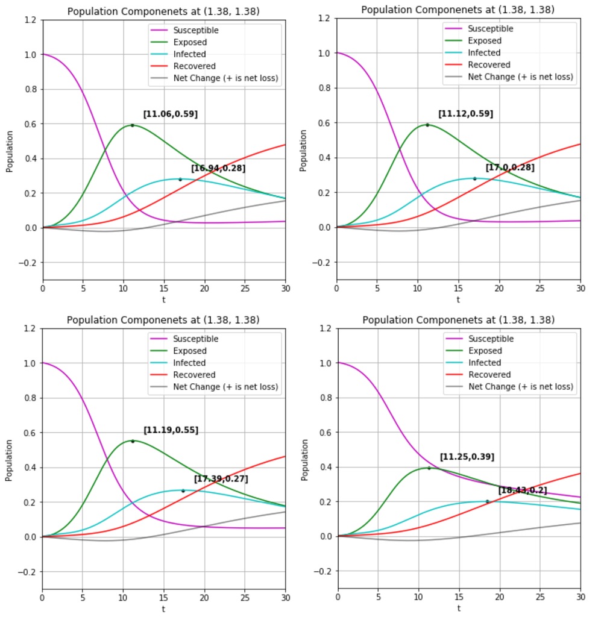

*Populations over time at a single point in the domain with $\omega$ = 0 (top left), 1 (top right), 10 (bottom left), and 100 (bottom right)*

| $\omega$ | 0 | 1 | 10 | 100 |
| --- | --- | --- | --- | --- |
| **Time of max Exposed** | 11.06 | 11.12 | 11.19 | 11.25 |
| **Time of max Infected** | 16.94 | 17.0 | 17.39 | 18.43 |
| **Max Exposed** | .59 | .59 | .55 | .39 |
| **Max Infected** | .28 | .28 | .27 | .2 |
| **Final (t = 30) Susceptible** | .03447 | .03568 | .04935 | .22423 |
| **Final (t = 30) Exposed** | .16704 | .16884 | .17606 | .18901 |
| **Final (t = 30) Infected** | .16868 | .16977 | .1708 | .15347 |
| **Final (t = 30) Recovered** | .47684 | .47465 | .46164 | .35964 |
| **Final (t = 30) Net Loss** | .15297 | .15107 | .14214 | .07364 |

These scenarios demonstrate the validity of "flattening the curve." The more that each individual responds to the growing Infected population, the lower the peak of Infected and Exposed individuals is and the longer they each take to peak. At first glance of the final populations, the higher $\omega$s have significantly less net loss, i.e., fewer casualties. However, looking at the other populations in conjunction with the graphs, you can see that the higher $\omega$s are actually just behind the others in their trajectories. The Recovered population is an indication of the proportion of the population that has had the virus and is expected to have a higher death rate. It is a better indicator than the Susceptible population because the only way into the Recovered population is via Infected, whereas the outflow of the Susceptible population due to the virus is muddled by the influx of births.

| ($\omega = 100$) Time | 10 | 20 | 30 | 40 | 50 |
| --- | --- | --- | --- | --- | --- |
| **Susceptible** | .47192 | .28768 | .22401 | .17779 | .14777 |
| **Exposed** | .38525 | .28528 | .18874 | .14349 | .11638 |
| **Infected** | .12257 | .19703 | .15327 | .11288 | .08778 |
| **Recovered** | .04684 | .21184 | .36021 | .45097 | .50281 |
| **Net Loss** | -0.02458 | .01818 | .07377 | .11486 | .14526 |

Letting the model run for longer demonstrates that for the same number of infections (Recovered ≈ .45), $\omega = 100$ results in fewer casualties.

### Varying Diffusion

For the following tests, the psychological factor $\omega = 10$. I simulated a travel ban by letting the diffusion coefficient $a(x,y) = .2$ everywhere on the domain except for a single column of grid points vertically down the center, where $a(x,y) = .01$. Next, to simulate stay-at-home orders in one region, I set half of the domain to have $a(x,y) = .2$ and the other half to have $a(x,y) = .01$. I tested both the case when the region initially infected self-quarantines and the case where the initially uninfected region preventatively stays at home. Note that the mitigating measures modeled by the diffusion coefficient is *independent* of the size of the Infected population at each point in the domain. On the other hand, the coefficient $\omega$ is entirely dependent on the population of Infected individuals. Thus, $\omega$ encapsulates individuals' behaviors due to the fear of getting sick (e.g., wearing masks, social distancing, voluntarily staying home), while the diffusion coefficient better reflects region-wide policies (e.g., enforced stay-at-home orders, closing of non-essential businesses).

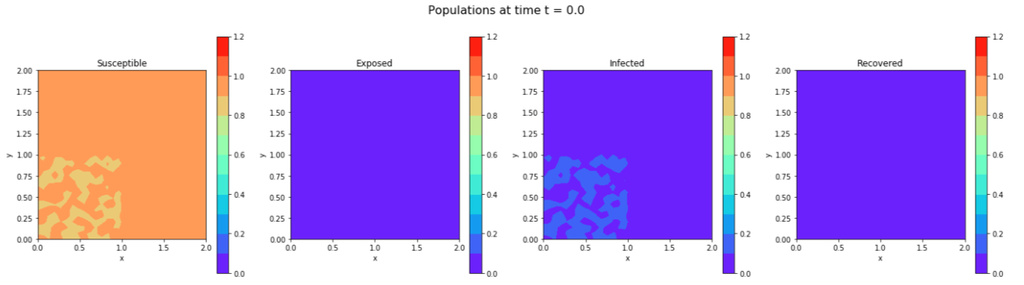

*Initialization*

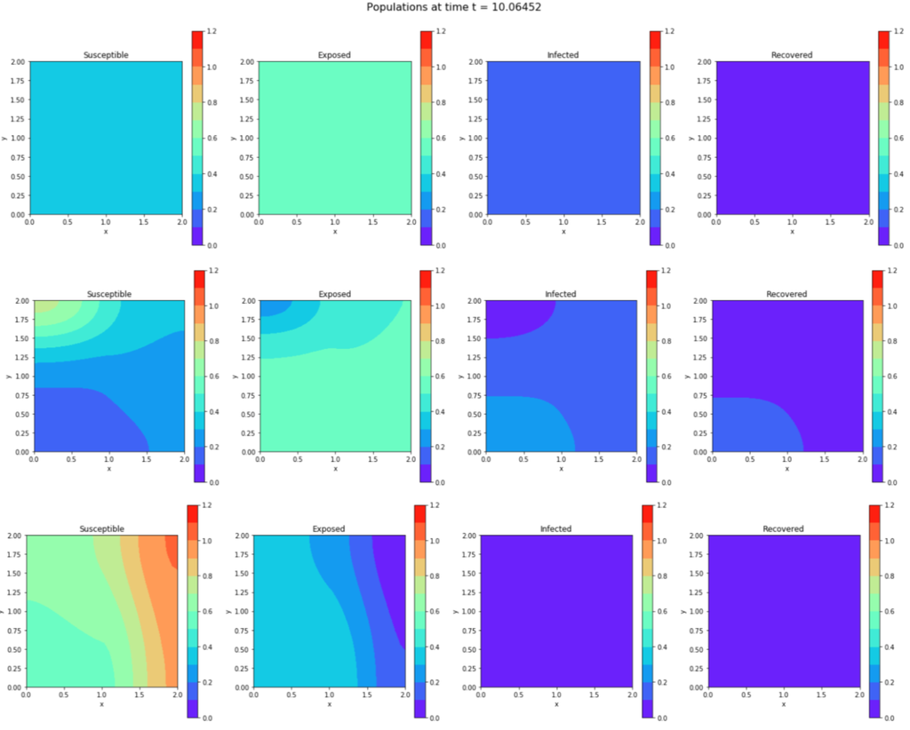

*Populations at time t = 10 with a travel ban (top), mitigating policies in initially infected side (middle), and preventative policy in the initially unaffected side (bottom).*

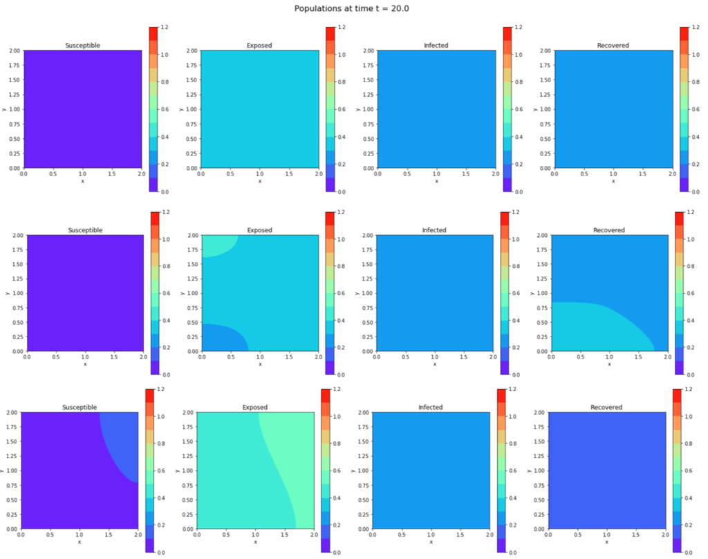

*Populations at time t = 20 with a travel ban (top), mitigating policies in initally infected side (middle), and preventative policies in the initially unaffected side (bottom).*

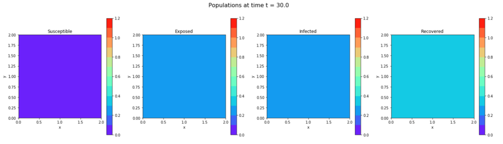

*Populations at time t = 30.*

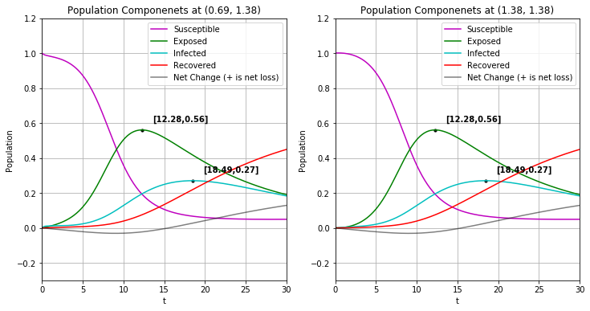

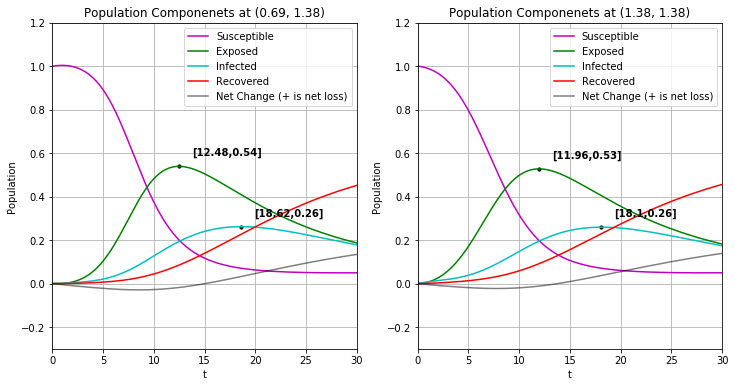

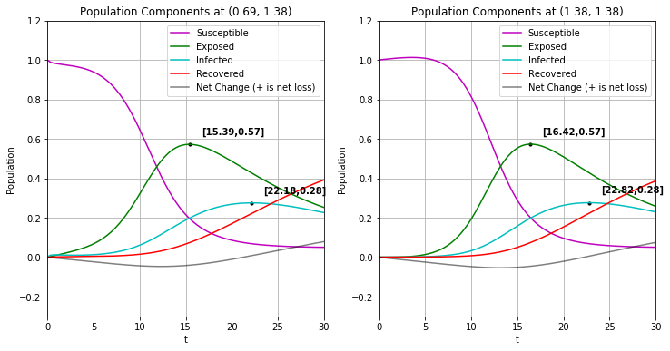

*Populations over time at a single point on each side of the domain in the cases of a travel ban (top), mitigating policies in initially infected side (middle), and preventative policies in the initially unaffected side (bottom).*

[output not shown]

Similar to the exploration into $\omega$, we let the model simulating Preventative Policy run for longer so that we get a better estimate for net population change when Recovered ≈ .45.

| Time | 8.6 (left) | 8.6 (right) | 17.2 (left) | 17.2 (right) | 25.7 (left) | 25.7 (right) | 34.3 (left) | 34.3 (right) | 42.9 (left) | 42.9 (right) |
| --- | --- | --- | --- | --- | --- | --- | --- | --- | --- | --- |
| **Susceptible** | .7865 | .92289 | .13821 | .17167 | .05536 | .05654 | .04986 | .04984 | .05586 | .05574 |
| **Exposed** | .20803 | .09966 | .55723 | .57125 | .33852 | .35038 | .19296 | .19598 | .12148 | .12229 |
| **Infected** | .03619 | .01601 | .23297 | .21407 | .26302 | .26658 | .18561 | .18804 | .11839 | .11926 |
| **Recovered** | .00878 | .00366 | .1047 | .08633 | .30348 | .29353 | .46067 | .45793 | .54511 | .54464 |
| **Net Loss** | -0.03949 | -0.04222 | -0.03311 | -0.04332 | .03962 | .03297 | .1109 | .1082 | .15916 | .15806 |

As you can see at time $t = 34.3$, the Recovered populations are ≈ .45 and the net loss is ≈.11 which is still lower than the other scenarios.

## Conclusions

From the simulations, we see that there is the lowest mortality when $\omega$ is large. We also found that all three large-scale interventions tested resulted in reduced mortality when compared to no intervention. Furthermore, preventative policies in the uninfected region had the best outcome for both regions, followed by travel ban, and lastly reactive policies. Note that the scenarios with the least deaths also took the longest to peak. For the psychological effect, the longer peaks were also lower. However, in the policy situations, the longer peaks were higher. It follows that the individual behaviors represented by $\omega$ do "flatten the curve," while the large-scale policy measures "delay the curve." Both of these effects result in reduced mortality in the simulation. Though availability of resources was not accounted for in the model, both flattening and delaying the curve would allow time for hospitals to prepare. Flattening the curve also reduces the stress on hospitals at the peak of the infection.

The main limitation of the model is the assumption that every individual will eventually contract the disease. This is one way in which future iterations may improve. Other possible additions include fitting the parameters to match data (e.g., from COVID-19), allowing parameters to depend on space (e.g., birth rate specific to countries, transmission dependent on socioeconomic status of neighborhoods) and/or time (e.g., waves caused by re-opening businesses, preparation of resources), or tracking the total infection-related deaths.

## Bibliography

Capasso, V., & Serio, G. (1978). A generalization of the Kermack-McKendrick deterministic epidemic model. *Mathematical Biosciences, 42*(1), 43–61. https://doi.org/10.1016/0025-5564(78)90006-8

Derrick, W. R., & van den Driessche, P. (1993). A disease transmission model in a nonconstant population. *Journal of Mathematical Biology, 31*(5), 495–512. https://doi.org/10.1007/BF00173889

Gumel, A. B., Ruan, S., Day, T., Watmough, J., Brauer, F., van den Driessche, P., Gabrielson, D., Bowman, C., Alexander, M. E., Ardal, S., Wu, J., & Sahai, B. M. (2004). Modelling strategies for controlling SARS outbreaks. *Proceedings of the Royal Society of London. Series B: Biological Sciences, 271*(1554), 2223–2232. https://doi.org/10.1098/rspb.2004.2800

Kermack, W. O., McKendrick, A. G., & Walker, G. T. (1927). A contribution to the mathematical theory of epidemics. *Proceedings of the Royal Society of London. Series A, Containing Papers of a Mathematical and Physical Character, 115*(772), 700–721. https://doi.org/10.1098/rspa.1927.0118

Miller Neilan, R., & Lenhart, S. (2011). Optimal vaccine distribution in a spatiotemporal epidemic model with an application to rabies and raccoons. *Journal of Mathematical Analysis and Applications, 378*(2), 603–619. https://doi.org/10.1016/j.jmaa.2010.12.035

Xiao, D., & Ruan, S. (2007). Global analysis of an epidemic model with nonmonotone incidence rate. *Mathematical Biosciences, 208*(2), 419–429. https://doi.org/10.1016/j.mbs.2006.09.025

Yang, Y., Zhou, J., & Hsu, C.-H. (2019). Threshold dynamics of a diffusive SIRI model with nonlinear incidence rate. *Journal of Mathematical Analysis and Applications, 478*(2), 874–896. https://doi.org/10.1016/j.jmaa.2019.05.059

## Appendix: Code for Figures

```python
from __future__ import print_function
%matplotlib inline

import numpy
import matplotlib.pyplot as plt
```

### Panic Coefficient

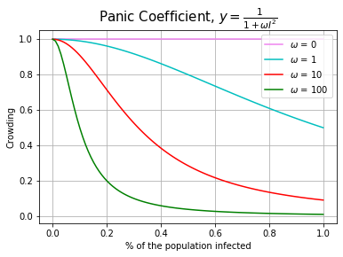

```python
L = 1

x = numpy.linspace(0, L, 100)
f = lambda omega, x: 1/(1 + omega*x**2)

fig = plt.figure()
axes = fig.add_subplot(1,1,1)

axes.plot(x, f(0, x), label = r'$\omega$ = 0', color = 'violet')
axes.plot(x, f(1, x), label = r'$\omega$ = 1', color = 'c')
axes.plot(x, f(10, x), label = r'$\omega$ = 10', color = 'r')
axes.plot(x, f(100, x), label = r'$\omega$ = 100', color = 'g')
axes.set_title(r'Panic Coefficient, $y = \frac {1} {1 + \omega I^2}$', size = 15)
axes.set_xlabel('% of the population infected')
axes.set_ylabel('Crowding')
axes.legend(loc = 1)
plt.grid()
plt.show()
```

### Model Runs

```python
def imex_solver(m, L, t_final, S_0, E_0, I_0, R_0, gamma, mu, kappa1,
                kappa2, sigma, delta, alpha, beta, omega, diff):
    """
    Computes population of each population component across a square domain over time.
    Graphs the population levels every few time steps.

    :Input:
     - *m* (int) number of grid points in each direction of the domain
     - *L* (int) length of each side of the domain

     - *S_0* (matrix) the initial susceptible population
     - *E_0* (matrix) the initial exposed population
     - *I_0* (matrix) the initial infected population
     - *R_0* (matrix) the initial recovered population

     - *gamma* (float) birth rate
     - *mu* (float) natural death rate
     - *kappa1* (float) transmission coefficient for exposed
     - *kappa2* (float) transmission coefficient for infected
     - *sigma* (float) rate of symptom development
     - *delta* (float) additional death rate of infected population due to illness
     - *alpha* (float) rate of recovery
     - *beta* (float) additional death rate of recovered population due to illness
     - *omega* (float) panic factor
     - *diff* (matrix) diffusion coefficient

     :Output:
      - *S* (matrix) susceptible population across the domain at the final time step
      - *E* (matrix) exposed population across the domain at the final time step
      - *I* (matrix) infected population across the domain at the final time step
      - *R* (matrix) recovered population across the domain at the final time step
    """

    # Alias reaction functions with the above parameters
    dS = lambda S, E, I, R: s_change(S, E, I, R, gamma, mu, kappa1, kappa2, omega)
    dE = lambda S, E, I, R: e_change(S, E, I, R, mu, kappa1, kappa2, omega, sigma)
    dI = lambda S, E, I, R: i_change(S, E, I, R, mu, sigma, delta, alpha)
    dR = lambda S, E, I, R: r_change(S, E, I, R, mu, alpha, beta)

    # Set up grid
    delta_x = L / (m + 1)
    x = numpy.linspace(0, L, m)
    y = numpy.linspace(0, L, m)
    Y, X = numpy.meshgrid(y, x)

    # Time
    t = 0.0
    delta_t = delta_x
    num_steps = int(numpy.round(t_final / delta_t))

    t_array = numpy.linspace(0, t_final, num_steps)
    s_time = numpy.zeros((len(t_array), 2))
    e_time = numpy.zeros((len(t_array), 2))
    i_time = numpy.zeros((len(t_array), 2))
    r_time = numpy.zeros((len(t_array), 2))
    d_time = numpy.zeros((len(t_array), 2))

    # Plot initial data
    levels = numpy.arange(0,1.3, .1)

    fig = plt.figure(figsize = (24,6))
    fig.suptitle(f'Populations at time t = {t}', fontsize=16)

    ICs = [S_0, E_0, I_0, R_0]
    populations = ['Susceptible', 'Exposed', 'Infected', 'Recovered']

    for n, pop in enumerate(populations):
        axes = fig.add_subplot(1, 4, n+1)
        axes.set_aspect('equal')
        CS = axes.contourf(X, Y, ICs[n], levels, cmap = 'rainbow')
        fig.colorbar(CS)
        axes.set_xlabel('x')
        axes.set_ylabel('y')
        axes.set_title(f'{pop}')
        axes.set_xlim([0,L])
        axes.set_ylim([0,L])
    plt.show()

    # Setup spatial discretization
    S = S_0.reshape(-1)
    E = E_0.reshape(-1)
    I = I_0.reshape(-1)
    R = R_0.reshape(-1)
    A = laplacian(L, m)


    # Evolve in time
    next_output_time = t_final/ 3
    for j in range(num_steps):
        # Take steps
        S, E, I, R = forward_euler_reaction_step(S, E, I, R, delta_t, dS, dE, dI, dR)
        S, E, I, R = backward_euler_diffusion_step(S, E, I, R, A, delta_t, diff)

        # Reshape and track points in either side
        S_output = S.reshape((m, m))
        s_time[j,0] = S_output[int(m/3),int(2*m/3)]
        s_time[j,1] = S_output[int(2*m/3),int(2*m/3)]

        E_output = E.reshape((m, m))
        e_time[j,0] = E_output[int(m/3),int(2*m/3)]
        e_time[j,1] = E_output[int(2*m/3),int(2*m/3)]

        I_output = I.reshape((m, m))
        i_time[j,0] = I_output[int(m/3),int(2*m/3)]
        i_time[j,1] = I_output[int(2*m/3),int(2*m/3)]

        R_output = R.reshape((m, m))
        r_time[j,0] = R_output[int(m/3),int(2*m/3)]
        r_time[j,1] = R_output[int(2*m/3),int(2*m/3)]

        # Define net pop
        D = numpy.ones((m,m))
        D -= (S_output + E_output + I_output + R_output)
        d_time[j,0] = D[int(m/3),int(2*m/3)]
        d_time[j,1] = D[int(2*m/3),int(2*m/3)]

        t += delta_t

        # Graph population levels
        if t >= next_output_time:
            next_output_time += t_final/ 3

            print('\nPopulations at time t = ', round(t, 3))
            print(f'Left side ({x[int(m/3)].round(2)}, {y[int(2*m/3)].round(2)}): ')
            print('\tSusceptible = ', round(s_time[j,0], 5))
            print('\tExposed = ', round(e_time[j,0], 5))
            print('\tInfected = ', round(i_time[j,0], 5))
            print('\tRecovered = ', round(r_time[j,0], 5))
            print('\tDead = ', round(d_time[j,0], 5))
            print(f'Right side ({x[int(2*m/3)].round(2)}, {y[int(2*m/3)].round(2)}): ')
            print('\tSusceptible = ', round(s_time[j,1], 5))
            print('\tExposed = ', round(e_time[j,1], 5))
            print('\tInfected = ', round(i_time[j,1], 5))
            print('\tRecovered = ', round(r_time[j,1], 5))
            print('\tDead = ', round(d_time[j,1], 5))

            fig = plt.figure(figsize = (24,6))
            fig.suptitle(f'Populations at time t = {round(t, 5)}', fontsize=16)

            matrices = [S_output, E_output, I_output, R_output]

            for n, pop in enumerate(populations):
                axes = fig.add_subplot(1, 4, n+1)
                axes.set_aspect('equal')
                CS = axes.contourf(X, Y, matrices[n], levels, cmap = 'rainbow')
                fig.colorbar(CS)
                axes.set_xlabel('x')
                axes.set_ylabel('y')
                axes.set_title(f'{pop}')
                axes.set_xlim([0,L])
                axes.set_ylim([0,L])


            plt.show()

    # Plot population levels over time (on either side of the country border)
    fig = plt.figure(figsize=(12,6))

    # define max
    top_e_left = numpy.argmax(e_time[:,0])
    top_i_left = numpy.argmax(i_time[:,0])

    axes = fig.add_subplot(1,2,1)
    axes.plot(t_array, s_time[:,0], label = 'Susceptible', color = 'm')
    axes.plot(t_array, e_time[:,0], label = 'Exposed', color = 'g')
    axes.plot(t_array, i_time[:,0], label = 'Infected', color = 'c')
    axes.plot(t_array, r_time[:,0], label = 'Recovered', color = 'r')
    axes.plot(t_array, d_time[:,0], label = 'Net Change (+ is net loss)',
              color = 'k', alpha = .5)
    # label max
    axes.scatter([t_array[top_e_left], t_array[top_i_left]],
              [e_time[top_e_left,0], i_time[top_i_left,0]], color = 'k',
                s = 10)
    axes.text(t_array[top_e_left+20], e_time[top_e_left,0]+.05,
              s = '[{},{}]'.format(round(t_array[top_e_left], 2),
                                   round(e_time[top_e_left,0], 2)),
             weight = 'bold')
    axes.text(t_array[top_i_left+20], i_time[top_i_left,0]+.05,
              s = '[{},{}]'.format(round(t_array[top_i_left], 2),
                                   round(i_time[top_i_left,0], 2)),
             weight = 'bold')

    axes.set_xlabel('t')
    axes.set_ylabel('Population')
    axes.set_title(f'Population Componenets at ({x[int(m/3)].round(2)}, {y[int(2*m/3)].round(2)})')
    axes.set_xlim([0,t_final])
    axes.set_ylim([-.3,1.2])
    axes.legend()
    axes.grid(True, which='both')


    # define max
    top_e_right = numpy.argmax(e_time[:,1])
    top_i_right = numpy.argmax(i_time[:,1])

    axes = fig.add_subplot(1,2,2)
    axes.plot(t_array, s_time[:,1], label = 'Susceptible', color = 'm')
    axes.plot(t_array, e_time[:,1], label = 'Exposed', color = 'g')
    axes.plot(t_array, i_time[:,1], label = 'Infected', color = 'c')
    axes.plot(t_array, r_time[:,1], label = 'Recovered', color = 'r')
    axes.plot(t_array, d_time[:,1], label = 'Net Change (+ is net loss)',
              color = 'k', alpha = .5)
    # label max
    axes.scatter([t_array[top_e_right], t_array[top_i_right]],
              [e_time[top_e_right,1], i_time[top_i_right,1]], color = 'k',
                s = 10)
    axes.text(t_array[top_e_right+20], e_time[top_e_right,1]+.05,
              s = '[{},{}]'.format(round(t_array[top_e_right], 2),
                                   round(e_time[top_e_right,1], 2)),
             weight = 'bold')
    axes.text(t_array[top_i_right+20], i_time[top_i_right,1]+.05,
              s = '[{},{}]'.format(round(t_array[top_i_right], 2),
                                   round(i_time[top_i_right,1], 2)),
             weight = 'bold')

    axes.set_xlabel('t')
    axes.set_ylabel('Population')
    axes.set_title(f'Population Componenets at ({x[int(2*m/3)].round(2)}, {y[int(2*m/3)].round(2)})')
    axes.set_xlim([0,t_final])
    axes.set_ylim([-.3,1.2])
    axes.legend()
    axes.grid(True, which='both')

    plt.show()

    return S_output, E_output, I_output, R_output
```

```python
# Set up parameters
gamma = .01 # birth rate
mu = .005 # natural death rate
kappa1 = .5 # transmission coefficient for exposed
kappa2 = .7 # transmission coefficient for infected
sigma = .1 # rate of symptom development (1/incubation time)
delta = .05 # additional death of infected population resulting from illness
alpha = .1 # recovery rate
beta = .005 # additional death of recovered population resulting from illness
omega = 1 # panic factor

L = 2
m = 30
t_final = 30

# Initial conditions
S_0 = numpy.zeros((m,m))
E_0 = numpy.zeros((m,m))
R_0 = numpy.zeros((m,m))
# Initial conditions (matrix) with spatial heterogeneity
for i in range(m):
    for j in range(m):
        S_0[i,j] = numpy.random.uniform(.8, 1) if i < m/2 and j < m/2 else 1
I_0 = numpy.ones((m,m)) - S_0

# Diffusion coefficients (matrix) with patial heterogeneity:
# Default:
diff = numpy.diag(numpy.ones(m**2)*.2, 0)
# Split horizontally (change left side)
for j in range(int(m**2 /2)):
    diff[j,j] = .5
# Travel ban down the center
for k in range(m):
    diff[int(m*(m-1)/2)+k, int(m*(m-1)/2)+k] /= 10

S, E, I, R = imex_solver(m, L, t_final, S_0, E_0, I_0, R_0, gamma, mu,
                         kappa1, kappa2, sigma, delta, alpha, beta, omega, diff)
```

### Convergence Tests

#### Laplacian

Solve $\nabla^2u = -2sin(x)sin(y)$ on $\Omega = [0, 2\pi] \times [0, 2\pi]$ with $u(x,y) = 0$ on the boundaries.

```python
def laplacian(L, m):
    """
    Constructs a sparse matrix that disretizes the 2D Laplacian.
    Uses a 9-point stencil and Dirichlet boundary conditions.

    :Input:
     - *L* (float) length of one side of the domain (assumes a square domain starting at the origin)
     - *m* (integer) number of points to use in the approximation

    :Output:
     - *A* (matrix) sparse matrix representation of discretized Laplacian
    """
    # Discretization
    delta_x = L / (m + 1)

    # Construct matrix components
    e = numpy.ones(m)

    T = sparse.spdiags([4*e, -20*e, 4*e],[-1,0,1], m, m)
    S = sparse.spdiags([e, 4*e, e],[-1,0,1], m, m)
    C = sparse.spdiags([e, e],[-1,1], m, m)
    I = numpy.diag(e, 0)

    # Assemble matrix
    A = sparse.kron(I, T) + sparse.kron(C, S)

    A /= (6*delta_x**2)
    A = A.todia()

    return A
```

```python
## Solve Laplace equation
def solve_poisson(A, L, f, m, top, bottom, right, left):
    # Spatial discretization
    x = numpy.linspace(0, L, m + 2)
    y = numpy.linspace(0, L, m + 2)
    delta_x = L / (m + 1)

    # Right-hand-side
    X, Y = numpy.meshgrid(x[1:-1], y[1:-1])
    b = f(X,Y)
    rhs = b.reshape(m**2, order='F')

    # Solve
    U = numpy.zeros((m + 2, m + 2))
    U[1:-1, 1:-1] = linalg.spsolve(A, rhs).reshape((m, m), order='F')


    return x, y, U
```

```python
## Compute and plot error

# Problem set up
L = 2*numpy.pi
f = lambda x, y: -2*numpy.sin(x)*numpy.sin(y)
u_true = lambda x, y: numpy.sin(x)*numpy.sin(y)
top = lambda x: 0
bottom = lambda x: 0
right = lambda y: 0
left = lambda y: 0

# Create $\Delta x$ and error arrays
delta_x = []
error = []
for N in range(50, 1000, 50):
    print(f'\nN = {N}:')
    # Define $\Delta x$ by uniform difference for N points
    delta_x.append(L / (N + 1))

    # Define x and U by solve function with N uniform grid points
    print(f'Computing Laplacian...')
    A = laplacian(L, N).tocsr()

    print(f'Solving Poisson equation...')
    x, y, U = solve_poisson(A, L, f, N, top, bottom, right, left)
    X, Y = numpy.meshgrid(x, y)

    # Add error between u_true and U to error array for each number of grid points
    error.append(numpy.linalg.norm((x[1] - x[0]) * (u_true(X, Y) - U), ord=1))
    print(f'Error = {numpy.linalg.norm((x[1] - x[0]) * (u_true(X, Y) - U), ord=1)}')


error = numpy.array(error)
delta_x = numpy.array(delta_x)
#Graph
fig = plt.figure()

axes = fig.add_subplot(1, 1, 1)
axes.loglog(delta_x, error, 'ko', label="Approx. Derivative")

order_C = lambda delta_x, error, order: numpy.exp(numpy.log(error) - order * numpy.log(delta_x))

axes.loglog(delta_x, order_C(delta_x[0], error[0], 1.0) * delta_x**1.0, 'r--', label="1st Order")
axes.loglog(delta_x, order_C(delta_x[0], error[0], 2.0) * delta_x**2.0, 'b--', label="2nd Order")
axes.legend(loc=4)
axes.set_title("Convergence of 9 point stencil")
axes.set_xlabel("$\Delta x$")
axes.set_ylabel("$|u(x) - U|$")

plt.show()
```

#### Backward Euler

Solve $u_t = \kappa u_{xx}$ on $\Omega = [0, 1]$

```python
## Solve heat equation (4 times)
def solve_heat_BE(m, kappa, L, t_0, t_final, S_0, E_0, I_0, R_0, g_0, g_1):
    # Discretize space and time
    delta_x = L / float(m + 1)
    delta_t = delta_x
    N = int(numpy.ceil((t_final - t_0) / delta_t))
    delta_t = (t_final - t_0) / N


    # Initial condition
    S = S_0.copy()
    E = E_0.copy()
    I = I_0.copy()
    R = R_0.copy()


    # Construct A for AU^n+1 = U^n
    r = kappa / (delta_x**2)
    e = numpy.ones(m + 2) * r

    A = numpy.zeros((m + 2,m + 2))
    A += numpy.diag(e[1:], -1)
    A += numpy.diag(-2 * e, 0)
    A += numpy.diag(e[1:], 1)

    A[0,0] = 1
    A[0,1] = 0
    A[-1,-1] = 1
    A[-1,-2] = 0

    # Diffusion coefficients
    diff = numpy.diag(numpy.ones(m + 2), 0)
    A = sparse.dia_matrix(A)
    A.tocsr()

    # Time stepping loop
    t = t_0
    for n in range(0, N ):
        S[0] = g_0(t + delta_t)
        S[-1] = g_1(t + delta_t)
        E[0] = g_0(t + delta_t)
        E[-1] = g_1(t + delta_t)
        I[0] = g_0(t + delta_t)
        I[-1] = g_1(t + delta_t)
        R[0] = g_0(t + delta_t)
        R[-1] = g_1(t + delta_t)

        S, E, I, R = backward_euler_diffusion_step(S, E, I, R, A, delta_t, diff)

        t += delta_t


    return S, E, I, R
```

```python
# Set up problem
beta = 150.0
kappa = 0.02
L = 1.0
t_0 = 0
t_final = 2

u_true = lambda x, t: numpy.exp(-(x - 0.4)**2. / (4.0 * kappa * t + 1.0 / beta)) \
                                            / numpy.sqrt(4.0 * kappa * beta * t + 1.0)
g_0 = lambda t: u_true(0, t)
g_1 = lambda t: u_true(L, t)


# Create delta_x and error arrays
delta_x = []
error = []
for N in range(50, 1000, 50):
    # Define delta_x
    x = numpy.linspace(0, L, N + 2)
    y = numpy.linspace(0, L, N + 2)
    X, Y = numpy.meshgrid(x, y)

    delta_x.append(L / (N + 1))

    # Initialize
    S_BE = u_true(x, 0.0)
    E_BE = u_true(x, 0.0)
    I_BE = u_true(x, 0.0)
    R_BE = u_true(x, 0.0)

    # Solve
    S_BE, E_BE, I_BE, R_BE = solve_heat_BE(N, kappa, L, t_0,
                                           t_final, S_BE, E_BE, I_BE, R_BE, g_0, g_1)

    # Add error between u_true and U to error array for each number of grid points
    error.append(numpy.linalg.norm((x[1] - x[0]) * (I_BE - u_true(x, t_final)), ord=1))

error = numpy.array(error)
delta_x = numpy.array(delta_x)

#Graph
fig = plt.figure()

axes = fig.add_subplot(1, 1, 1)
axes.loglog(delta_x, error, 'ko', label="Approx. Derivative")

order_C = lambda delta_x, error, order: numpy.exp(numpy.log(error) - order * numpy.log(delta_x))

axes.loglog(delta_x, order_C(delta_x[0], error[0], 1.0) * delta_x**1.0, 'r--', label="1st Order")
axes.loglog(delta_x, order_C(delta_x[0], error[0], 2.0) * delta_x**2.0, 'b--', label="2nd Order")
axes.legend(loc=4)
axes.set_title("Convergence of Backward Euler")
axes.set_xlabel("$\Delta x$")
axes.set_ylabel("$|u(x) - S|$")

plt.show()
```

#### Forward Euler

Solve $u_t = -u$ on $\Omega = [0,10]$

```python
# Set up problem
c_0 = 1.0
decay_constant = numpy.log(2.0) / 1600.0
f = lambda u, x, y , z: -decay_constant * u

t_exact = numpy.linspace(0.0, 1.6e3, 100)
u_exact = c_0 * numpy.exp(-decay_constant * t_exact)

# Initialize
t = numpy.linspace(0.0, 1.6e3, 10)
delta_t = t[1] - t[0]

S = numpy.empty((len(t), len(t)))
S[0,:] = c_0 * numpy.ones_like(t)

E = numpy.empty((len(t), len(t)))
E[0,:] = c_0 * numpy.ones_like(t)

I = numpy.empty((len(t), len(t)))
I[0,:] = c_0 * numpy.ones_like(t)

R = numpy.empty((len(t), len(t)))
R[0,:] = c_0 * numpy.ones_like(t)

# Implement Forward Euler
for n in range(len(t) - 1):
    S[n + 1,:], E[n + 1,:], I[n + 1,:], R[n + 1,:] = forward_euler_reaction_step(S[n,:], E[n,:], I[n,:], R[n,:],
                                                                         delta_t, f, f, f, f)
```

```python
# Set up problem
f = lambda  u, x, y, z: -u
u_exact = lambda t: numpy.exp(-t)
u_0 = 1.0

t_f = 10.0
num_steps = [2**n for n in range(4,10)]
# Define delta_t and error arrays
delta_t = numpy.empty(len(num_steps))
error = numpy.empty(len(num_steps))

for (i, N) in enumerate(num_steps):
    t = numpy.linspace(0, t_f, N)
    delta_t[i] = t_f/float(N+1)

    # Initialize solution vectors
    S = numpy.empty((len(t), len(t)))
    S[0,:] = u_0 * numpy.ones_like(t)

    E = numpy.empty((len(t), len(t)))
    E[0,:] = u_0 * numpy.ones_like(t)

    I = numpy.empty((len(t), len(t)))
    I[0,:] = u_0 * numpy.ones_like(t)

    R = numpy.empty((len(t), len(t)))
    R[0,:] = u_0 * numpy.ones_like(t)

    # Compute Forward Euler solution
    for n in range(len(t) - 1):
        S[n + 1,:], E[n + 1,:], I[n + 1,:], R[n + 1,:] = forward_euler_reaction_step(S[n,:], E[n,:], I[n,:], R[n,:],
                                                                             delta_t[i], f, f, f, f)

    error[i] = numpy.linalg.norm(delta_t[i] * (S[:,-1] - u_exact(t)), ord=1)

error = numpy.array(error)
delta_t = numpy.array(delta_t)

#Graph
fig = plt.figure()

axes = fig.add_subplot(1, 1, 1)
axes.loglog(delta_t, error, 'ko', label="Approx. Derivative")

order_C = lambda delta_t, error, order: numpy.exp(numpy.log(error) - order * numpy.log(delta_t))

axes.loglog(delta_t, order_C(delta_t[0], error[0], 1.0) * delta_t**1.0, 'r--', label="1st Order")
axes.loglog(delta_t, order_C(delta_t[0], error[0], 2.0) * delta_t**2.0, 'b--', label="2nd Order")
axes.legend(loc=4)
axes.set_title("Convergence of Forward Euler")
axes.set_xlabel("$\Delta t$")
axes.set_ylabel("$|u(x) - S|$")

plt.show()
```